# Un petit cours sur les graphiques (avec ggplot)

Christophe Benavent

26 janvier 2020

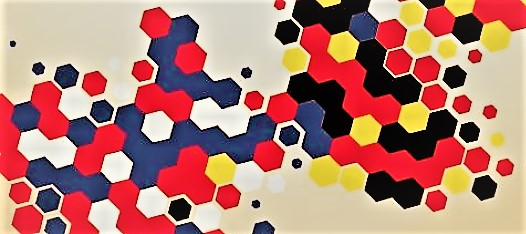

confiance

# Préparation des données

On fait quelques opérations de recodage et on renomme les variables avoir une lecture plus aisée des variables et de leurs catégories. On appele au début les bibliothèques. La principale est [tidyverse](https://www.tidyverse.org/) qui est un bouquet de packages comprenant ggplot - dont voici le [book de référence](https://ggplot2-book.org/), qui est au centre de ce cours, et [dplyr](http://larmarange.github.io/analyse-R/manipuler-les-donnees-avec-dplyr.html) qui va nous permettre de manipuler les données aisément.(On recommande de jeter un coup d’oeil appuyés sur ces deux liens qui peuvent servir de manuels techniques)

```r
knitr::opts_chunk$set(echo = TRUE, include=TRUE, cache=TRUE, message=FALSE, warning=FALSE, cache=TRUE)
library(tidyverse)
library(gridExtra)
df<-readRDS("mastermoi.rds")
write.csv(df,"mastermoi", row.names = TRUE)

#quelques recodages
#on renomme pour plus de clarte
names(df)[names(df)=="trstun"] <- "NationsUnies"
names(df)[names(df)=="trstep"] <- "ParlementEurop"
names(df)[names(df)=="trstlgl"] <- "Justice"
names(df)[names(df)=="trstplc"] <- "Police"
names(df)[names(df)=="trstplt"] <- "Politiques"
names(df)[names(df)=="trstprl"] <-"Parlement"
names(df)[names(df)=="trstprt"] <- "Partis"
names(df)[names(df)=="pplhlp"] <- "help"
names(df)[names(df)=="pplfair"] <- "fair"
names(df)[names(df)=="ppltrst"] <- "trust"

#on construit les scores de confiance
df<-df %>% mutate(trust_institut=(Partis+Parlement+Politiques+Police+Justice+NationsUnies+ParlementEurop)*10/7)

df<-df %>% mutate(trust_interpersonnel=(help+fair+trust)*10/3)

#recodage des variables indépendantes
df$Year[df$essround==1]<-2002
```

```r
df$Year[df$essround==2]<-2004
df$Year[df$essround==3]<-2006
df$Year[df$essround==4]<-2008
df$Year[df$essround==5]<-2010
df$Year[df$essround==6]<-2012
df$Year[df$essround==7]<-2014
df$Year[df$essround==8]<-2016
df$Year[df$essround==9]<-2018

df$Year<-as.factor(df$Year)

#ggplot(df,aes(x=lrscale))+geom_histogram()
df$OP[df$lrscale==0] <- "Extrême gauche"
df$OP[df$lrscale==1] <- "Gauche"
df$OP[df$lrscale==2] <- "Gauche"
df$OP[df$lrscale==3] <- "Centre Gauche"
df$OP[df$lrscale==4] <- "Centre Gauche"
df$OP[df$lrscale==5] <- "Ni G ni D"
df$OP[df$lrscale==6] <- "Centre Droit"
df$OP[df$lrscale==7] <- "Centre Droit"
df$OP[df$lrscale==8] <- "Droite"
df$OP[df$lrscale==9] <- "Droite"
df$OP[df$lrscale==10] <- "Extrême droite"
#la ligne suivante est pour ordonner les modalités de la variables
df$OP<-factor(df$OP,levels=c("Extrême droite","Droite","Centre Droit","Ni G ni D","Centre Gauche","Gauche","Extrême gauche"))


df$rev<-df$hincfel
df$revenu[df$hincfel>4] <- NA
df$revenu[df$hincfel==1] <- "Vie confortable"
df$revenu[df$hincfel==2] <- "Se débrouille avec son revenu"
df$revenu[df$hincfel==3] <- "Revenu insuffisant"
df$revenu[df$hincfel==4] <- "Revenu très insuffisant"
df$revenu<-factor(df$revenu,levels=c("Vie confortable","Se débrouille avec son revenu","Revenu insuffisant","Revenu très insuffisant"))

df$habitat[df$domicil==1]<- "Big city"
df$habitat[df$domicil==2]<-"Suburbs"
df$habitat[df$domicil==3]<-"Town"
df$habitat[df$domicil==4]<-"Village"
df$habitat[df$domicil==5]<-"Countryside"
df$habitat<-factor(df$habitat,levels=c("Big city","Suburbs","Town","Village","Countryside"))

df$genre[df$gndr==1]<-"H"
df$genre[df$gndr==2]<-"F"

df$age[df$agea<26]<-"25<"
df$age[df$agea>25 & df$agea<36]<-"26-35"
df$age[df$agea>35 & df$agea<46]<-"36-45"
df$age[df$agea>45 & df$agea<66]<-"46-65"
df$age[df$agea>65 & df$agea<76]<-"66-75"
df$age[df$agea>75]<-"75>"
df$age<-factor(df$age,levels=c("25<","26-35","36-45","46-65","66-75", "75>"))
```

# Analyse univariée

L’analyse univarié, comme son nom l’indique, ne s’intéresse qu’à une seule variable. Celle-ci peut être **quantitative** et quasi continue ou **qualitative** variables quantitatives et ne comporter qu’un nombre limité de modalités entre lesquels aucune comparaison de grandeur ne peut être faite. Les première ont le plus souvent dans r un format numeric, les autres correspondent au format *factor*.

## Le cas des variables quantitatives

Les variables quantitatives décrivent une variable dont les valeurs décrivent les quantités d’une unité. Elle peuvent être discrète ( exemple dénombrement du d’un nombre d’unités - le nombre d’habitant), continue - le nombre de km parcouru).

### Histogramme

C’est l’outil de base pour représenter la distribution d’une variable quantitative, l’**histogramme** qui le graphe élémentaire de l’analyse statistique. Il représente pour des intervalles de valeurs donnés, la fréquences des observations.

Sa syntaxe simple comporte d’abord la défnition de la variable et de la source de données, puis une des “géométrie” de ggplot : la fonction geom_histogram.

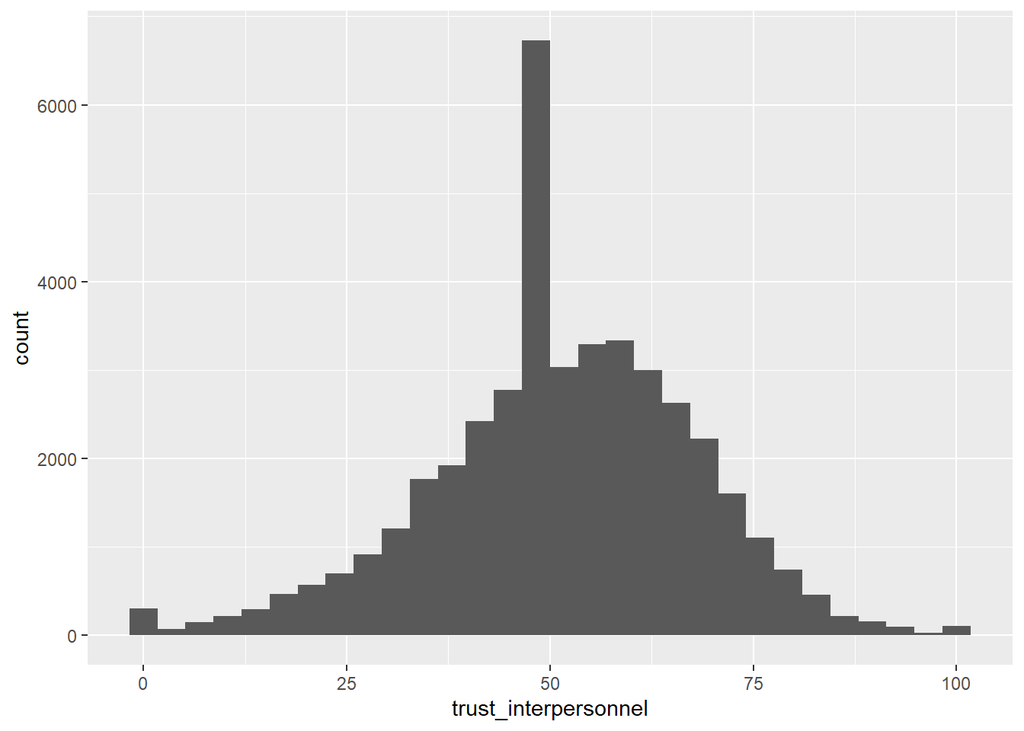

```r
# on stocke le diagramme dans l'objet (g00<-), pour le réutiliser ultérieurement et pouvoir le compléter.
g00<-ggplot(df,aes(x=trust_interpersonnel))+
  geom_histogram()
g00
```

On va améliorer l’aspect en a) modifiant la couleur et la largeur des barres, b) ajoutant un thème et c) en précisant les éléments textuels ( titres, label).

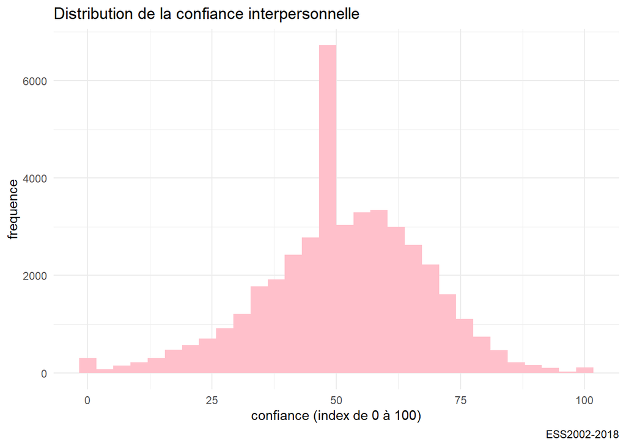

```r
#avec tous les éléments
g02 <-g00+geom_histogram(binwith=5,fill="pink")+
  theme_minimal()+
  labs(title= "Distribution de la confiance interpersonnelle", caption="ESS2002-2018",y= "frequence",x="confiance (index de 0 à 100)")
g02
```

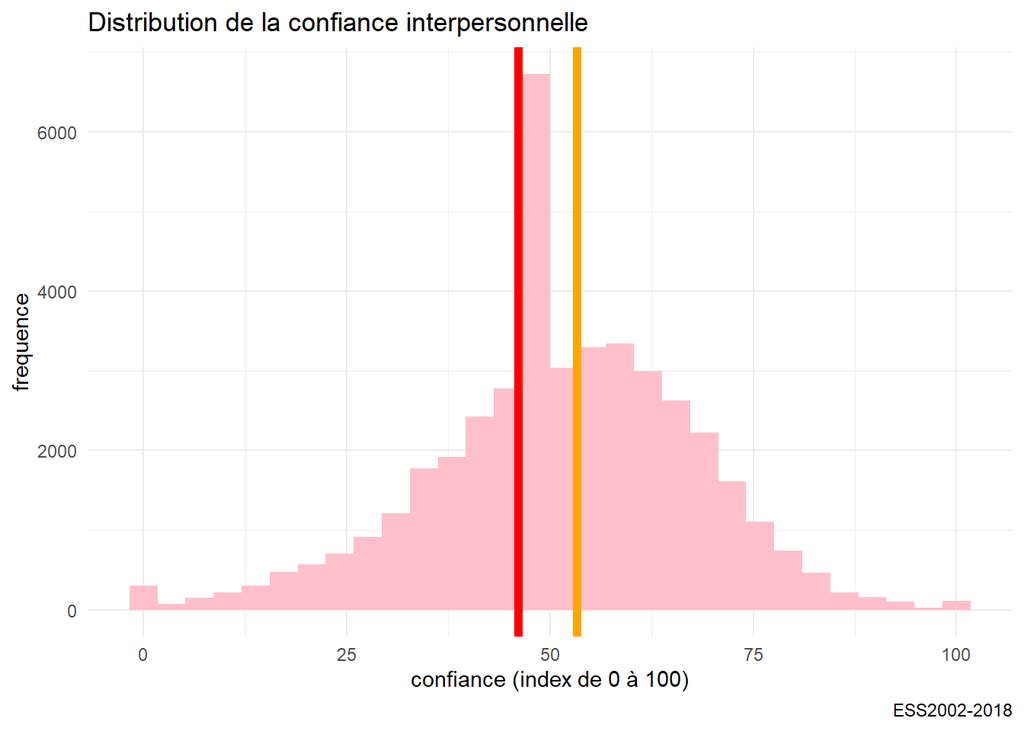

```r
#on calcule la moyenne
moy=mean(df$trust_institut, na.rm=TRUE)
median=median(df$trust_interpersonnel,na.rm=TRUE)

#on ajoute la lignn des moyenne
g03<- g02+geom_vline(xintercept=moy, color="red",size=2)+
  geom_vline(xintercept=median, color="orange",size=2)
g03
```

diagramme de densité : Au lieu de représenter les effectifs, on ramène l’effectif total à 1.

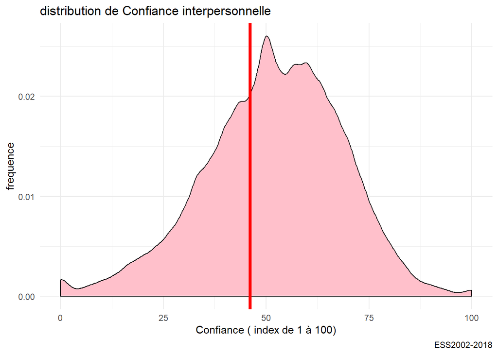

```r
g04<-ggplot(df,aes(x=trust_interpersonnel))+
  geom_density(binwidth=10, fill="pink") +
  theme_minimal()+
  labs(title= "distribution de Confiance interpersonnelle", caption="ESS2002-2018",y= "frequence",x="Confiance ( index de 1 à 100)")

g04<- g04+ geom_vline(xintercept=moy, color="red",size=1.5)
g04
```

On en profite pour regrouper les deux graphes en un seul avec la fonction grid.arrange qui permet très simplement de grouper plusieurs graphes en un seul. Ici on mesure les amélioration à partir du graphe par défaut.

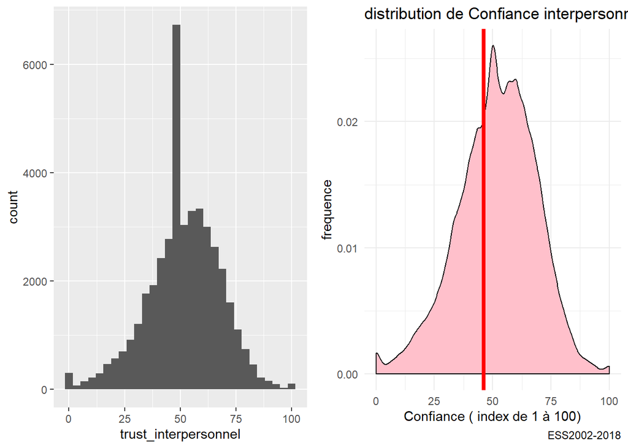

```r
grid.arrange(g00, g04, ncol=2)
```

enfin on peut examiner par rapport à une distribution théorique ajustement de distribution théorique

[figure not shown]

```r
g05<-ggplot(df,aes(x=trust_interpersonnel))+
  geom_density(fill="pink")+
  stat_function(fun = dnorm,color="red",size=1.2, args = list(mean =moy, sd=sd))+
  theme_minimal()
g05
```

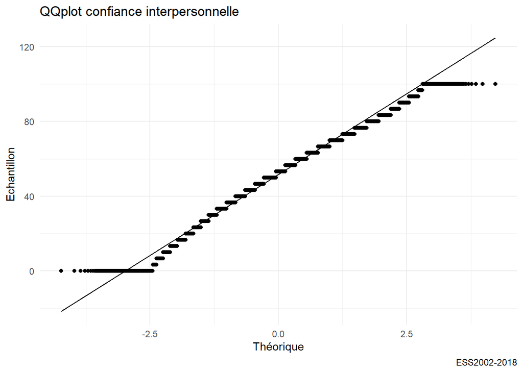

```r
g06 <- ggplot(df, aes(sample = trust_interpersonnel)) + stat_qq() + stat_qq_line()+theme_minimal()+  labs(title= "QQplot confiance interpersonnelle", caption="ESS2002-2018",y= "Echantillon",x="Théorique")
g06
```

On fini cette étude détaillée par l’ajustement d’un modèle (loi normale) aux données.

```r
df0<-df %>% na.omit()
library(MASS)
fit<-fitdistr(df0$trust_interpersonnel,"normal")
fit
```

```
##       mean           sd
##   52.48548790   16.57617220
##  ( 0.09344363) ( 0.06607462)
```

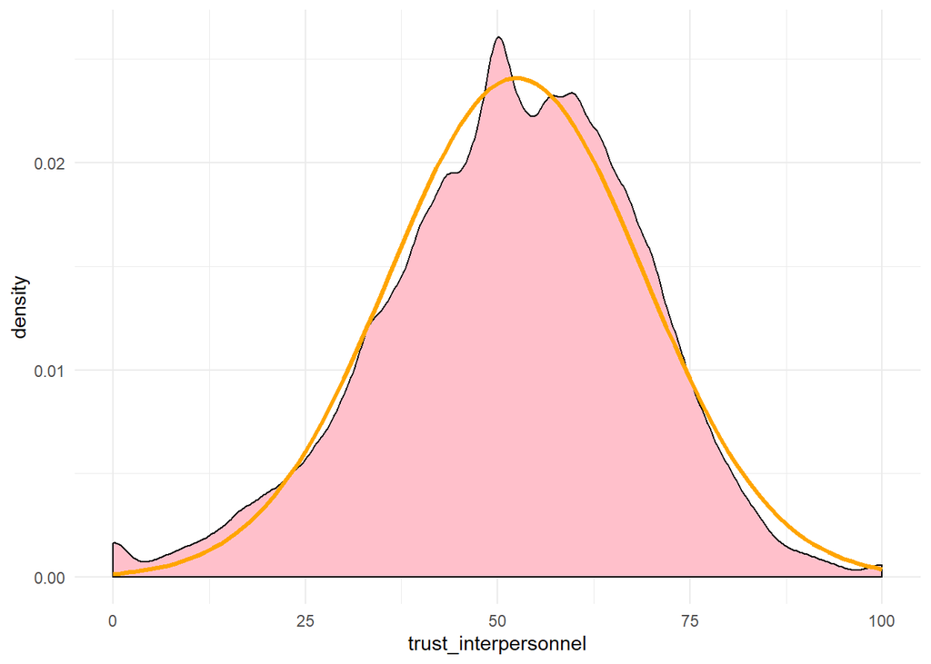

```r
g07<- g05+stat_function(fun =  dnorm ,color="orange",size=1.2, args = list( mean=52.48,  sd=16.57))
g07
```

### Quand la variable est qualitative

Quand la variable est qualitative, que ses variables sont discrètes, la manière de représenter la plus commune est le fameux camembert que les experts écartent. Un diagramme en barre représente mieux les proportions.

Un premier exemple pour représenter les vagues d’enquetes

```r
g08<-ggplot(df,aes(x=Year))+
  geom_bar(fill="skyblue")+
  theme_minimal()+
  labs(title= "Evolution de la confiance interpersonnelle", caption="ESS2002-2018",y= "frequence",x="Vague d'enquête")

geom_text(stat='count', aes(label=..count..), vjust=+2)
```

```
## mapping: label = ~..count..
## geom_text: parse = FALSE, check_overlap = FALSE, na.rm = FALSE
## stat_count: na.rm = FALSE
## position_identity
```

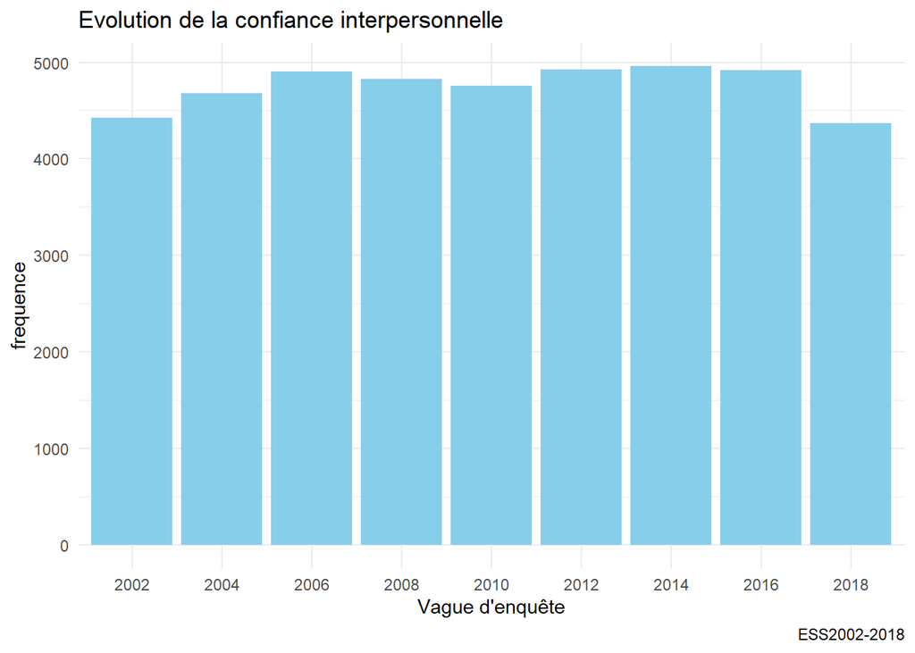

```r
g08
```

Un second exemple pour les ages avec une nouveauté : la rotation à 90°C.

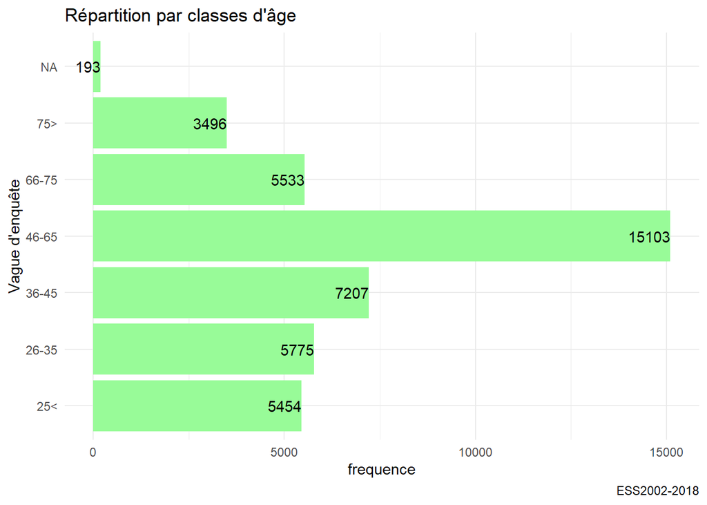

```r
g09a<-ggplot(df,aes(x=age))+geom_bar(fill="palegreen")+theme_minimal()+
geom_text(stat='count', aes(label=..count..), hjust=1) + coord_flip()+
 labs(title= "Répartition par classes d'âge", caption="ESS2002-2018",y= "frequence",x="Vague d'enquête")

g09a
```

en % et en 2 jeux de couleurs standard et couleur

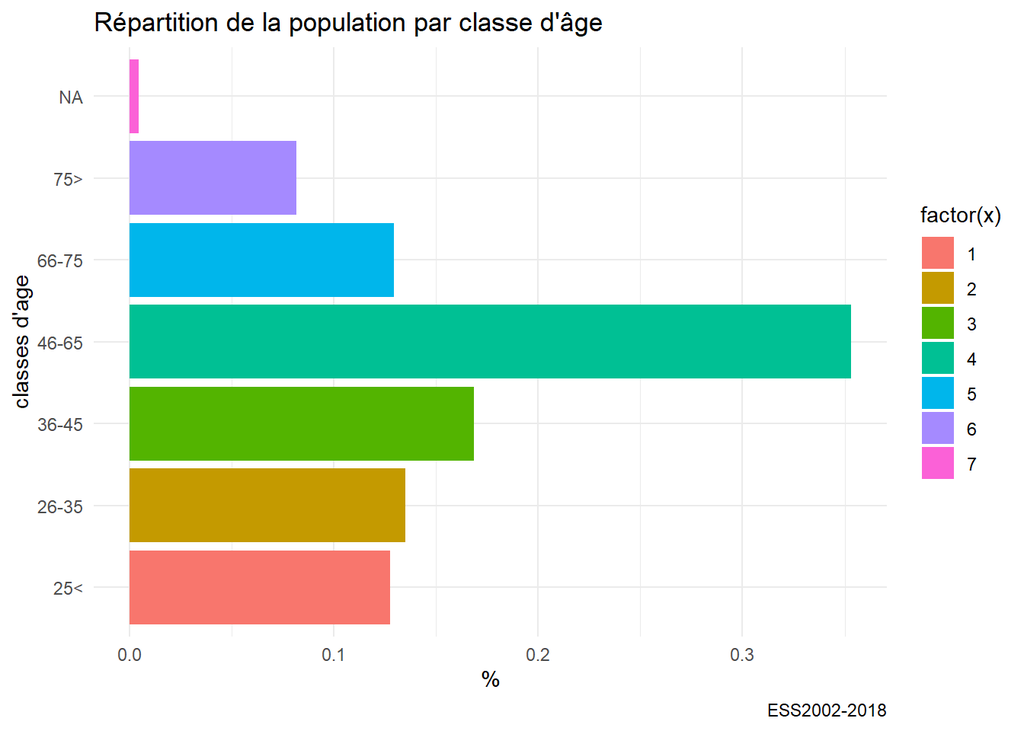

```r
g10<-ggplot(df,aes(x=age))+geom_bar(aes(y = (..count..)/sum(..count..),fill = factor(..x..))) +theme_minimal()+coord_flip()+
  labs(title= "Répartition de la population par classe d'âge", caption="ESS2002-2018",y= "%",x="classes d'age")

g10
```

si on tient au diagramme en cercle, autant opter pour un treemap avec la bibliothèque treemapifi

https://cran.r-project.org/web/packages/treemapify/vignettes/introduction-to-treemapify.html

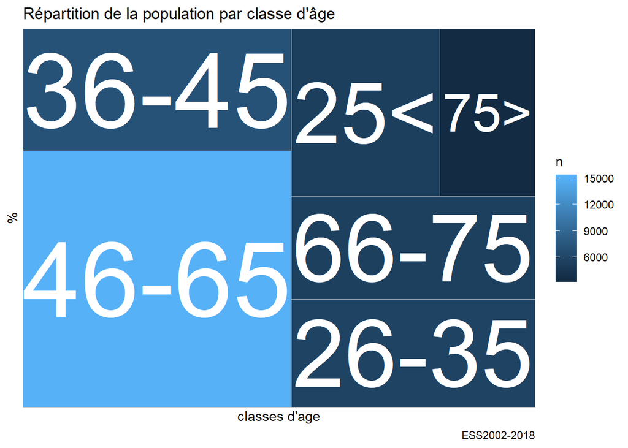

```r
library(treemapify)
tree1<-df %>% mutate(n=1)%>%group_by(age) %>% summarize(n=sum(n)) %>%filter(!is.na(age))
g11 <- ggplot(tree1, aes(area = n, fill=n),label=age) +
  geom_treemap() +   geom_treemap_text(aes(label=age),colour = "white", place = "centre",grow = TRUE)+
  labs(title= "Répartition de la population par classe d'âge", caption="ESS2002-2018",y= "%",x="classes d'age")

g11
```

# Analyse bivariée

on commence

1. par comparer des distribution de plusieurs groupes (variables catégorielles)
2. par comparer des moyennes d’une variable dépendante en fonction de plusieurs variables indépendantes catégorielle
3. par mesurer la corrélation entre deux variable quantitative
4. mesurer l’association entre deux variables qualitatives

### Comparer les distributions

Dans notre base on a melangé les données de l’Allemagne et de la France. On va comparer leur distribution.

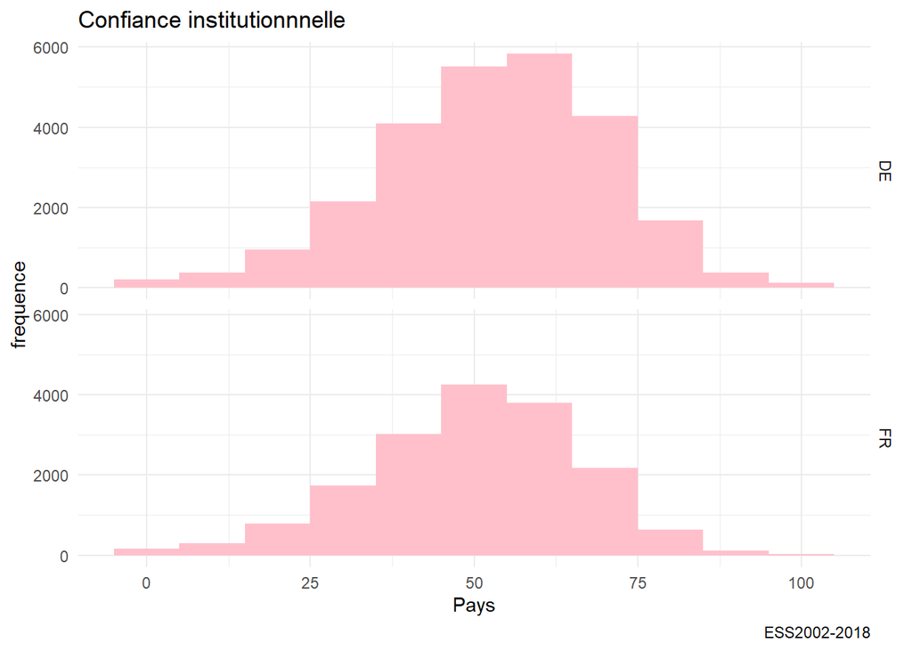

```r
#on recode en facteur la variable

df$cntry<-as.factor(df$cntry)

#on peut utiliser "facet"
g20<-ggplot(df,aes(x=trust_interpersonnel))+ geom_histogram(binwidth=10, fill="pink")+ facet_grid(cntry~.)+  theme_minimal()+
  labs(title= "Confiance institutionnnelle", caption="ESS2002-2018",y= "frequence",x="Pays")
g20
```

mais pour comparer des distribution faut mieux classiquement un boxplot

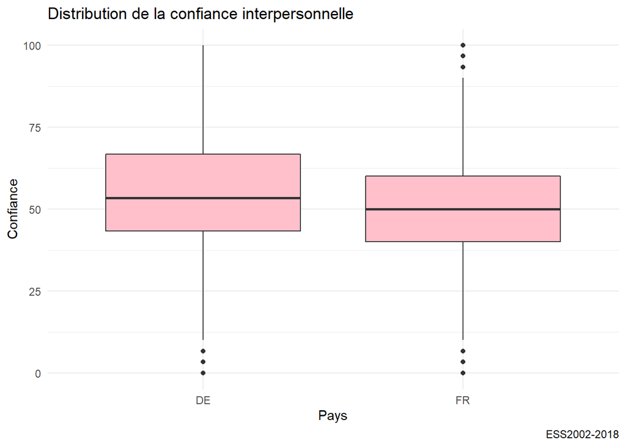

```r
#les boxplot

g21<-ggplot(df,aes(x=cntry, y=trust_interpersonnel))+ geom_boxplot( fill="pink") +
  theme_minimal()+
  labs(title= "Distribution de la confiance interpersonnelle",subtile="boxplot", caption="ESS2002-2018",y= "Confiance",x="Pays")
g21
```

ou encore plus modern un diagramme en violin

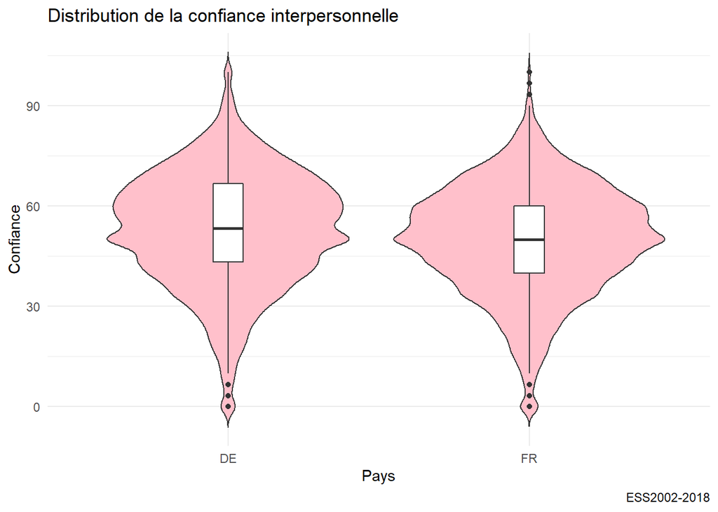

```r
# une variante : les violin plot
g22<-ggplot(df,aes(x=cntry, y=trust_interpersonnel))+ geom_violin( fill="pink", trim=FALSE) +  theme_minimal()+
  geom_boxplot(width=0.1, fill="white")+
  labs(title= "Distribution de la confiance interpersonnelle",subtile="boxplot", caption="ESS2002-2018",y= "Confiance",x="Pays")
g22
```

encore plus raffiné comparer les pays mais aussi les genres avec facet grid qui permet d’éclater les représentation par pays.

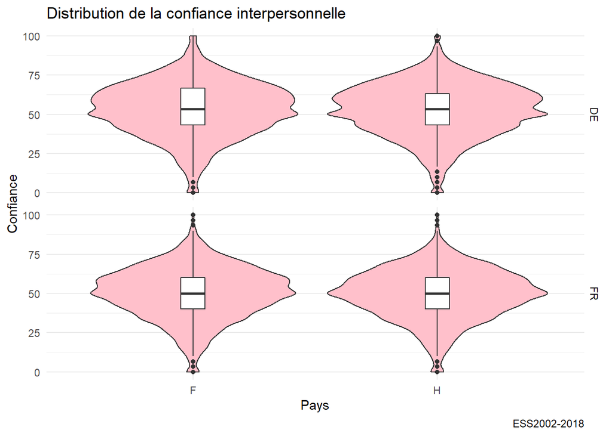

```r
# une variante : les violin plot
g23<-ggplot(df,aes(x=genre, y=trust_interpersonnel))+
  geom_violin( fill="pink") +
  theme_minimal()+
  geom_boxplot(width=0.1, fill="white")+
  labs(title= "Distribution de la confiance interpersonnelle",subtile="boxplot", caption="ESS2002-2018",y= "Confiance",x="Pays")+
  facet_grid(cntry~.)
g23
```

### Comparaison de moyennes

```r
df_wave<-df %>%
  group_by(age) %>%
  summarise(moyenne=mean(trust_interpersonnel, na.rm=TRUE))%>%
  filter(!is.na(age))
df_wave
```

```
## # A tibble: 6 x 2
##   age   moyenne
##   <fct>   <dbl>
## 1 25<      52.6
## 2 26-35    50.7
## 3 36-45    51.2
## 4 46-65    51.5
## 5 66-75    52.2
## 6 75>      54.2
```

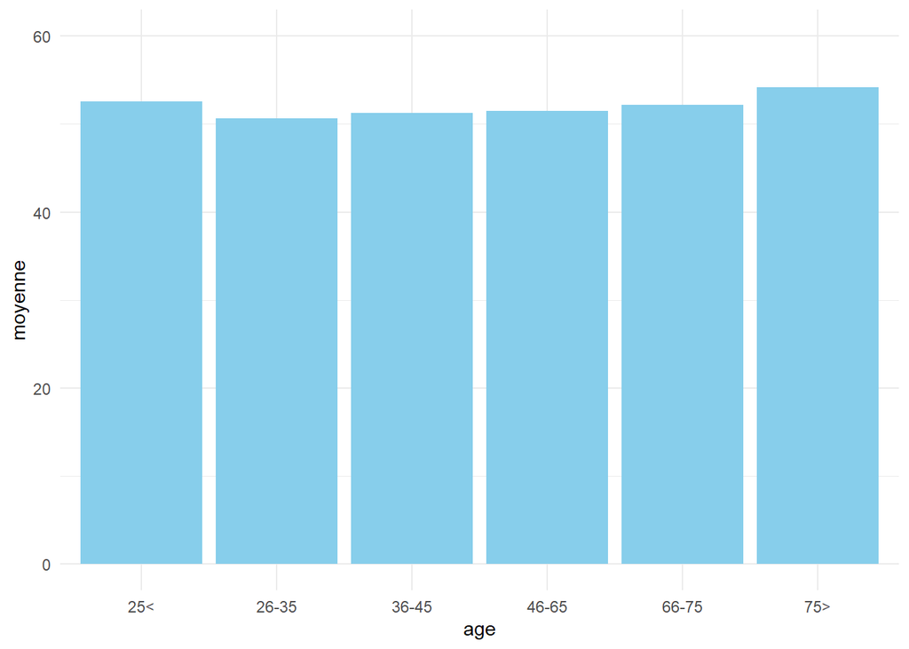

```r
g06a<-ggplot(df_wave,aes(x=age,y=moyenne))+geom_bar(stat="identity",fill="skyblue")+theme_minimal()+ylim(0,60)
g06a
```

```r
df_wave2<-df %>% group_by(age,cntry) %>%
  summarise(moyenne=mean(trust_interpersonnel, na.rm=TRUE)) %>%
  filter(!is.na(age))

df_wave2
```

```
## # A tibble: 12 x 3
## # Groups:   age [6]
##    age   cntry moyenne
##    <fct> <fct>   <dbl>
##  1 25<   DE       53.5
##  2 25<   FR       50.9
##  3 26-35 DE       52.1
##  4 26-35 FR       48.9
##  5 36-45 DE       52.5
##  6 36-45 FR       49.4
##  7 46-65 DE       53.1
##  8 46-65 FR       49.1
##  9 66-75 DE       53.3
## 10 66-75 FR       50.5
## 11 75>   DE       55.3
## 12 75>   FR       52.9
```

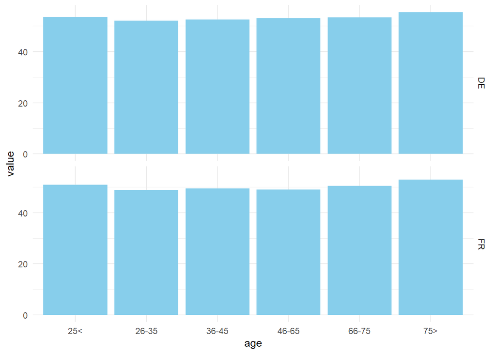

```r
library(reshape2)
df_wave2<-melt(df_wave2)
g06a<-ggplot(df_wave2,aes(x=age,y=value))+geom_bar(stat="identity",fill="skyblue")+theme_minimal()+facet_grid(cntry~.)
g06a
```

Une présentation en ligne est cependant bien meilleure et beaucoups plus lisible.

(PS/ si une seule série alors group=1 )

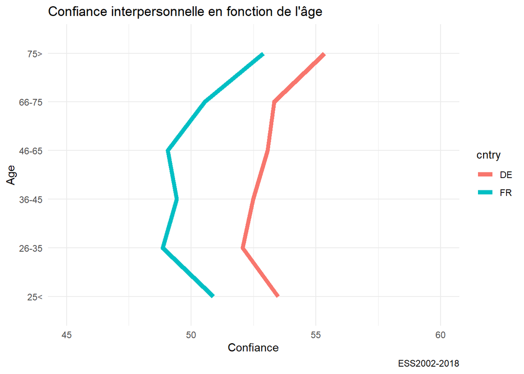

```r
g06b<-ggplot(df_wave2,aes(x=age,y=value, group=cntry))+geom_path(aes(color=cntry),stat="identity", size=2)+
  theme_minimal()+
  ylim(45,60)+
  labs(title= "Confiance interpersonnelle en fonction de l'âge", caption="ESS2002-2018",y= "Confiance",x="Age") +coord_flip()

g06b
```

et tant qu’à faire regardons aussi l’évolution de la confiance institutionnnells les deux formes

```r
df_wave3<-df %>% group_by(Year,cntry) %>%
  summarise(moy_institu=mean(trust_institut, na.rm=TRUE),moy_interp=mean(trust_interpersonnel, na.rm=TRUE))  %>%
  filter(!is.na(cntry))

library(reshape2)
df_wave3<-melt(df_wave3)
df_wave3
```

```
##    Year cntry    variable    value
## 1  2002    DE moy_institu      NaN
## 2  2002    FR moy_institu      NaN
## 3  2004    DE moy_institu 44.98339
## 4  2004    FR moy_institu 43.77759
## 5  2006    DE moy_institu 44.69956
## 6  2006    FR moy_institu 44.04121
## 7  2008    DE moy_institu 47.54171
## 8  2008    FR moy_institu 45.45535
## 9  2010    DE moy_institu 45.13884
## 10 2010    FR moy_institu 42.95088
## 11 2012    DE moy_institu 48.92897
## 12 2012    FR moy_institu 44.07173
## 13 2014    DE moy_institu 48.45095
## 14 2014    FR moy_institu 42.49401
```

[output cut: 22 more lines]

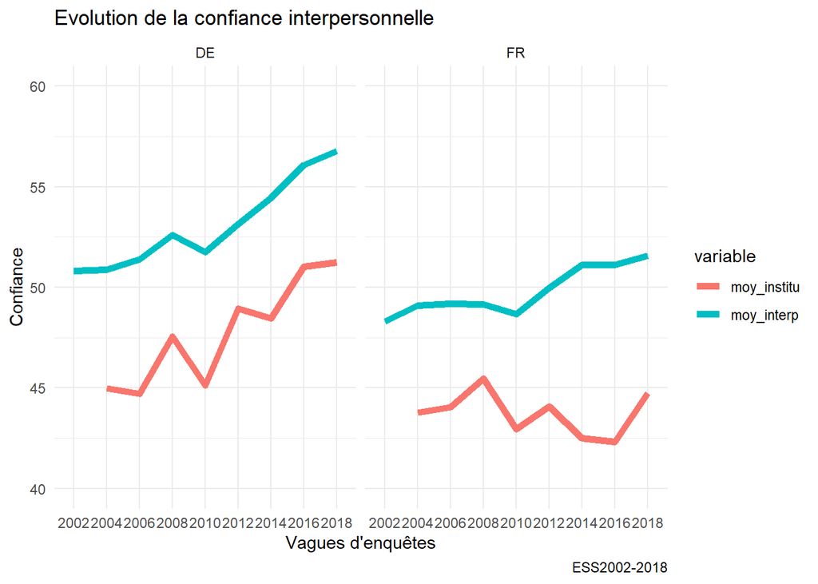

```r
g11<-ggplot(df_wave3,aes(x=Year,y=value, group=variable))+geom_path(stat="identity", aes(color=variable),size=2)+theme_minimal()+ylim(40,60)+facet_grid(.~cntry)+
  labs(title= "Evolution de la confiance interpersonnelle", caption="ESS2002-2018",y= "Confiance",x="Vagues d'enquêtes")
g11
```

On a commencé par le plus difficile. Comparer l’évolution de deux catégories sur une variable puis deux variables.